# Cooking similarity - études et exploitation des données (1)

Ce notebook explique les différentes étapes de tris et extraction du jeu de données "full_format_recipes.json".

Il s'agit d'un jeu de données de 20 000 recettes extraites du site [Epicurious](https://www.epicurious.com/).

Ce jeu de données nous permet de travailler sur des recettes diverses avec plusieurs informations tel que les valeurs nutritionnelles, la note de la recette, les ingrédients, catégories...

## Source

Jeu de données obtenu sur: https://www.kaggle.com/hugodarwood/epirecipes

## Contenu

Plus de 20 000 recettes listées selon l’évaluation de la recette, l’information nutritionnelle et la(les) catégorie(s) attribuée(s) etc...

```python
import numpy as np
import pandas as pd
from pandas import read_csv
from IPython.display import Image

df = pd.read_json("full_format_recipes.json")
```

```python
df.head()
```

|  | calories | categories | date | desc | directions | fat | ingredients | protein | rating | sodium | title |
| --- | --- | --- | --- | --- | --- | --- | --- | --- | --- | --- | --- |
| 0 | 426.0 | [Sandwich, Bean, Fruit, Tomato, turkey, Vegeta... | 2006-09-01 04:00:00 | None | [1. Place the stock, lentils, celery, carrot, ... | 7.0 | [4 cups low-sodium vegetable or chicken stock,... | 30.0 | 2.500 | 559.0 | Lentil, Apple, and Turkey Wrap |
| 1 | 403.0 | [Food Processor, Onion, Pork, Bake, Bastille D... | 2004-08-20 04:00:00 | This uses the same ingredients found in boudin... | [Combine first 9 ingredients in heavy medium s... | 23.0 | [1 1/2 cups whipping cream, 2 medium onions, c... | 18.0 | 4.375 | 1439.0 | Boudin Blanc Terrine with Red Onion Confit |
| 2 | 165.0 | [Soup/Stew, Dairy, Potato, Vegetable, Fennel, ... | 2004-08-20 04:00:00 | None | [In a large heavy saucepan cook diced fennel a... | 7.0 | [1 fennel bulb (sometimes called anise), stalk... | 6.0 | 3.750 | 165.0 | Potato and Fennel Soup Hodge |
| 3 | NaN | [Fish, Olive, Tomato, Sauté, Low Fat, Low Cal,... | 2009-03-27 04:00:00 | The Sicilian-style tomato sauce has tons of Me... | [Heat oil in heavy large skillet over medium-h... | NaN | [2 tablespoons extra-virgin olive oil, 1 cup c... | NaN | 5.000 | NaN | Mahi-Mahi in Tomato Olive Sauce |
| 4 | 547.0 | [Cheese, Dairy, Pasta, Vegetable, Side, Bake, ... | 2004-08-20 04:00:00 | None | [Preheat oven to 350°F. Lightly grease 8x8x2-i... | 32.0 | [1 12-ounce package frozen spinach soufflé, th... | 20.0 | 3.125 | 452.0 | Spinach Noodle Casserole |

## Tris des données

Nous avons trié les données par catégories pour obtenir des jeux de données plus petits afin de les exploiter et les afficher dans notre interface web. Avoir des jeux de données plus petits nous permet aussi d'étudier précisément certaines catégories en particuliers, faire un tri... Les jeux de données doivent contenir des catégories de recette pertinente tel que "Tarte", "Pâte" ou "Cookie" de sorte à montrer une certaine diversité dans les ingrédients, les directions...

Voici le détail de notre analyse afin de générer les différents jeux de données:

Trier les recettes par catégories:

```python
#Nombre de résultats par catégorie
def getNumbersOfRecipeByCategories(df):
    result = {}

    for categoriesList in df.categories:

        # check if it is really a list of categories
        if not isinstance(categoriesList, list):
            # if not, skip
            continue

        for categorie in categoriesList:
            if categorie in result:
                result[categorie] += 1
            else:
                result[categorie] = 1
    return result
```

```python
d = getNumbersOfRecipeByCategories(df)
d["Bean"]
```

```
577
```

```python
sorted_countbycategoriesDict = sorted(getNumbersOfRecipeByCategories(df).items(), key=operator.itemgetter(1), reverse=True)
dFrame = pd.DataFrame(sorted_ingredientsDict, columns=['Categorie','Frequency'])
dFrame.head()
```

|  | Categorie | Frequency |
| --- | --- | --- |
| 0 | Bon Appétit | 9355 |
| 1 | Peanut Free | 8390 |
| 2 | Soy Free | 8088 |
| 3 | Tree Nut Free | 7044 |
| 4 | Vegetarian | 6846 |

La liste ci-dessus nous donne les 5 catégories ayant le plus de recettes. Il existe des catégories qui sont moins pertinentes tel que des ingrédients comme "Onion","Tomato"... ou qui possède très peu de résultats (<200).

Pour obtenir la catégorie contenant le plus de recettes:

```python
import operator
recipeCategCount = getNumbersOfRecipeByCategories(df)
max(recipeCategCount, key=recipeCategCount.get)
```

```
'Bon Appétit'
```

On remarque que la catégorie possédant le plus de recette est "Bon Appétit". Cette catégorie n'est pas pertinente car elle peut rassembler plusieurs recettes différentes qui n'ont aucune similarité comme on peut le voir sur le site d'Epicurious en allant dans cette catégorie:

[figure not shown]

```python
Image(filename="images/categorie_bonappetit.png")
```

Le but est donc de trouver des recettes qui ont des bases similaires mais qui présentent aussi des variantes.

Trier les catégories par ordre décroissant de nombre de recettes:

```python
# Ordre decroissant
# sorted_recipeCategCount = sorted(recipeCategCount.items(), key=operator.itemgetter(1))

# Ordre croissant
sorted_recipeCategCount = sorted(recipeCategCount.items(), key=operator.itemgetter(1), reverse=True)
dFrame2 = pd.DataFrame(sorted_recipeCategCount, columns=['Categorie','Frequency'])
dFrame2.head()
```

|  | Categorie | Frequency |
| --- | --- | --- |
| 0 | Bon Appétit | 9355 |
| 1 | Peanut Free | 8390 |
| 2 | Soy Free | 8088 |
| 3 | Tree Nut Free | 7044 |
| 4 | Vegetarian | 6846 |

En regardant la liste des catégories triées on peut ainsi dégager des catégories interessantes tel que:

1. 'Pasta' avec 968 recettes de pâtes.
2. 'Sandwich' avec 428 recettes de sandwich.
3. 'Cookies' avec 273 recettes de cookies. Nous allons donc ensuite générer les jeu de données en json pour ces 3 catégories:

Génération des fichier json:

```python
def keepCategorie(df, categorie):
    rowToDelete = []
    for row, categories in enumerate(df.categories):
        if not isinstance(categories, list):
            rowToDelete.append(row)
        elif not categorie in categories:
                rowToDelete.append(row)

    df = df.drop(rowToDelete)
    return df
```

### Génération du fichier "Pasta.json".

```python
# On veut garder seulement les pasta
df_pasta = keepCategorie(df,'Pasta')

# Avec le reset_index(drop=True) on reinitialise les index à partir de 0.
df_pasta.reset_index(drop=True).to_json('Pasta.json',orient='records')
pasta = pd.read_json("Pasta.json")
pasta.head()
```

|  | calories | categories | date | desc | directions | fat | ingredients | protein | rating | sodium | title |
| --- | --- | --- | --- | --- | --- | --- | --- | --- | --- | --- | --- |
| 0 | 547.0 | [Cheese, Dairy, Pasta, Vegetable, Side, Bake, ... | 2004-08-20 04:00:00 | None | [Preheat oven to 350°F. Lightly grease 8x8x2-i... | 32.0 | [1 12-ounce package frozen spinach soufflé, th... | 20.0 | 3.125 | 452.0 | Spinach Noodle Casserole |
| 1 | NaN | [Milk/Cream, Cheese, Leafy Green, Pasta, Bake,... | 2009-11-02 04:00:00 | None | [Heat oil in heavy large skillet over medium h... | NaN | [3 tablespoons extra-virgin olive oil, 8 ounce... | NaN | 3.750 | NaN | Pancetta and Taleggio Lasagna with Treviso |
| 2 | NaN | [Cheese, Herb, Pasta, Low Cal, Dinner, Lunch, ... | 2013-11-13 04:00:00 | "Creamy squash and cheese crisps only make you... | [Heat oven to 375°. On a parchment paper-lined... | NaN | [6 tablespoons shredded Parmesan, 8 ounces she... | NaN | 5.000 | NaN | Fontina Mac with Squash and Sage |
| 3 | 634.0 | [Fish, Leafy Green, Pasta, Tomato, Bake, Quick... | 2005-10-01 04:00:00 | Kristi Parnell of San Marcos, California, writ... | [Preheat oven to 425°F. Whisk 2 tablespoons oi... | 31.0 | [4 tablespoons extra-virgin olive oil, divided... | 44.0 | 4.375 | 181.0 | Baked Halibut with Orzo, Spinach, and Cherry T... |
| 4 | 684.0 | [Cheese, Dairy, Garlic, Herb, Pasta, Vegetable... | 2004-08-20 04:00:00 | None | [Preheat oven to 450°F. and oil 2 large shallo... | 42.0 | [3 pounds butternut squash, quartered, seeded,... | 21.0 | 4.375 | 637.0 | Roasted Butternut Squash, Rosemary, and Garlic... |

### Génération du fichier "Sandwich.json"

```python
# On veut garder seulement les sandwich
df_sw = keepCategorie(df,'Sandwich')
df_sw.reset_index(drop=True).to_json('Sandwich.json',orient='records')
sw = pd.read_json("Sandwich.json")
sw.head()
```

|  | calories | categories | date | desc | directions | fat | ingredients | protein | rating | sodium | title |
| --- | --- | --- | --- | --- | --- | --- | --- | --- | --- | --- | --- |
| 0 | 426.0 | [Sandwich, Bean, Fruit, Tomato, turkey, Vegeta... | 2006-09-01 04:00:00.000 | None | [1. Place the stock, lentils, celery, carrot, ... | 7.0 | [4 cups low-sodium vegetable or chicken stock,... | 30.0 | 2.500 | 559.0 | Lentil, Apple, and Turkey Wrap |
| 1 | 948.0 | [Sandwich, Food Processor, Tomato, Kid-Friendl... | 2004-08-20 04:00:00.000 | This recipe can be prepared in 45 minutes or l... | [Mix basil, mayonnaise and butter in processor... | 79.0 | [2 1/2 cups (lightly packed) fresh basil leave... | 19.0 | 4.375 | 1042.0 | The Best Blts |
| 2 | 904.0 | [Sandwich, Beef, Cheese, Mushroom, Mustard, Qu... | 2004-08-20 04:00:00.000 | None | [Mix cheese and green onions in medium bowl. G... | 70.0 | [1 cup shredded mozzarella cheese, 1/4 cup fin... | 38.0 | 4.375 | 1413.0 | Veal Burgers Stuffed with Mozzarella Cheese |
| 3 | 641.0 | [Sandwich, Beef, Cheese, Leafy Green, Onion, Q... | 2004-08-20 04:00:00.000 | None | [Mash first 3 ingredients in small bowl until ... | 37.0 | [1 cup crumbled Stilton cheese, 2 tablespoons ... | 39.0 | 4.375 | 907.0 | Grilled Roast Beef and Stilton Sandwich |
| 4 | 959.0 | [30 Days of Groceries, Chickpea, Salad, Sandwi... | 2016-04-21 18:04:13.025 | This recipe is part of our Spring Grocery Bag ... | [Whisk mayonnaise, oil, lemon zest, and lemon ... | 60.0 | [3 tablespoons mayonnaise, 2 tablespoons extra... | 21.0 | 3.750 | 1541.0 | Chickpea Salad Sandwich With Creamy Carrot-Rad... |

### Génération du fichier "Cookie.json"

```python
# On veut garder seulement les cookies
df_cookie = keepCategorie(df,'Cookies')
df_cookie.reset_index(drop=True).to_json('Cookies.json',orient='records')
cookie = pd.read_json("Cookies.json")
cookie.head()
```

|  | calories | categories | date | desc | directions | fat | ingredients | protein | rating | sodium | title |
| --- | --- | --- | --- | --- | --- | --- | --- | --- | --- | --- | --- |
| 0 | 129.0 | [Cookies, Rum, Cheese, Dairy, Fruit, Dessert, ... | 2004-08-20 12:48:48 | To bake these puffs all at once, you will need... | [Cut butter into 1/4-inch slices. In a large b... | 9.0 | [4 sticks (2 cups) cold unsalted butter, 4 cup... | 1.0 | 4.375 | 34.0 | Banana Rum Puffs |
| 1 | 105.0 | [Cookies, Food Processor, Fruit, Dessert, Bake... | 2004-08-20 04:00:00 | These cookies are perfect with a cup of tea. | [Combine first 3 ingredients in processor; ble... | 7.0 | [1 cup all purpose flour, 4 ounces chilled cre... | 1.0 | 3.125 | 31.0 | Cream Cheese Strudel Cookies |
| 2 | 87.0 | [Cookies, Dessert, Bake, Christmas, Kid-Friend... | 2011-12-22 04:00:00 | When it comes right down to it, the simplest h... | [Beat together butter, sugar, and salt in a la... | 4.0 | [2 sticks (1 cup) unsalted butter, softened, 1... | 1.0 | 3.750 | 26.0 | Buttery Sugar Cookies |
| 3 | 92.0 | [Cookies, Nut, Dessert, Bake, Christmas, Kid-F... | 2013-11-06 04:00:00 | Hand off this dough to the kids—or anyone with... | [Place racks in lower and upper thirds of oven... | 6.0 | [1 1/2 cups all-purpose flour, 1 1/2 cups unsa... | 1.0 | 4.375 | 51.0 | Roasted-Almond Thumbprints |
| 4 | 76.0 | [Bon Appétit, Bake, Cookies, Almond, Lemon, De... | 2016-07-01 18:35:00 | These traditional almond cookies hail from Tus... | [Preheat oven to 350°F. Toast almonds on a rim... | 5.0 | [1 1/4 cups slivered almonds, 1 teaspoon finel... | 2.0 | 0.000 | 15.0 | Tuscan Almond Cookies (Ricciarelli) |

Afin de tester avec le minimum de données (et pas un fichier json de plus de 200 à 900 résultats...)nous avons créé un fichier "Test" avec quelques données:

```python
#Générer json avec 5 recettes
cookie = pd.read_json("Cookies.json")
head_cookie= cookie.head()
head_cookie.to_json('Cookies_small.json',orient='records')
data_small = pd.read_json("Cookies_small.json")
data_small
```

|  | calories | categories | date | desc | directions | fat | ingredients | protein | rating | sodium | title |
| --- | --- | --- | --- | --- | --- | --- | --- | --- | --- | --- | --- |
| 0 | 129 | [Cookies, Rum, Cheese, Dairy, Fruit, Dessert, ... | 2004-08-20 12:48:48 | To bake these puffs all at once, you will need... | [Cut butter into 1/4-inch slices. In a large b... | 9 | [4 sticks (2 cups) cold unsalted butter, 4 cup... | 1 | 4.375 | 34 | Banana Rum Puffs |
| 1 | 105 | [Cookies, Food Processor, Fruit, Dessert, Bake... | 2004-08-20 04:00:00 | These cookies are perfect with a cup of tea. | [Combine first 3 ingredients in processor; ble... | 7 | [1 cup all purpose flour, 4 ounces chilled cre... | 1 | 3.125 | 31 | Cream Cheese Strudel Cookies |
| 2 | 87 | [Cookies, Dessert, Bake, Christmas, Kid-Friend... | 2011-12-22 04:00:00 | When it comes right down to it, the simplest h... | [Beat together butter, sugar, and salt in a la... | 4 | [2 sticks (1 cup) unsalted butter, softened, 1... | 1 | 3.750 | 26 | Buttery Sugar Cookies |
| 3 | 92 | [Cookies, Nut, Dessert, Bake, Christmas, Kid-F... | 2013-11-06 04:00:00 | Hand off this dough to the kids—or anyone with... | [Place racks in lower and upper thirds of oven... | 6 | [1 1/2 cups all-purpose flour, 1 1/2 cups unsa... | 1 | 4.375 | 51 | Roasted-Almond Thumbprints |
| 4 | 76 | [Bon Appétit, Bake, Cookies, Almond, Lemon, De... | 2016-07-01 18:35:00 | These traditional almond cookies hail from Tus... | [Preheat oven to 350°F. Toast almonds on a rim... | 5 | [1 1/4 cups slivered almonds, 1 teaspoon finel... | 2 | 0.000 | 15 | Tuscan Almond Cookies (Ricciarelli) |

### Remarque:

En regardant les résultats des fichier générés on vérifie bien que les intitulés des recettes correspondent.

Par exemple si on prend cette ligne de "Cookies.json" qui correspond à une recette au nom de "Roasted-Almond Thumbprints" on peut se douter qu'il ne s'agisse pas d'une recette de cookie.

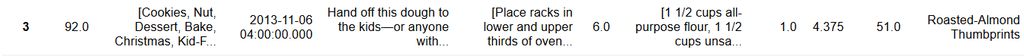

```python
Image(filename="images/ligne_roastedalmond.png")
```

et qu'on vérifie sur le site d'épicurious:

[figure not shown]

```python
Image(filename="images/roasted_almond.png")
```